# Widgets and Healthcare

Maximilian Lorbiecki

November 16, 2016

```r
library(plyr)
library(dplyr)
```

```r
library(tidyr)
library(ggplot2)
source("http://peterhaschke.com/Code/multiplot.R")
```

## Loading and Cleaning the Data

```r
HS<-read.csv("HealthSpending.csv")
```

```r
HS=rename(HS, Continent=ISO.country.code)
HS$Continent<-countrycode::countrycode(HS$Continent,"iso2c","continent")
HS[118,2] <- "Africa"
HS=rename(HS, Country=Location)
HS=rename(HS, pGDP=Health.spending....of.GDP)
HS=rename(HS, pGovSpendHealth=Government.spending.on.health.as...of.all.heath.spending)
HS=rename(HS, pPrivSpendHealth=Private.spending.on.health.as...of.all.health.spending)
HS=rename(HS, pGovSpendAll=Gov.spending.on.health.as...of.all.spending)
HS=rename(HS, pOPSpendpAll=Health.spending.out.of.pocket..as...of.all.health.spending)
HS=rename(HS, pPPSpendpAll=Private.prepaid.plans.as...of.private.spending.on.health)
HS=rename(HS, pcTotalHealth=Per.capita.total.spending.on.health..PPP.int....)
HS=rename(HS, pcGovHealth=Per.capita.government.spending.on.health..PPP.int....)
HS=rename(HS, tDoctors=Total.doctors)
HS=rename(HS, tNursesMidwivesPer10000=Nurses.and.midwives..per.10.000.pop)
HS=rename(HS, tDoctorsPer10000=Doctors..per.10.000.population)
HS=rename(HS, tNursesMidwives=Total.nurses.and.midwives)
```

## Introduction

In this report we are given the global healthcare spending and outcomes in 2010 data procured from the World Health Organization via the Guardian’s datablog. With this data set we are asked to evaluate four tasks.

1. Which countries spend more on healthcare?
2. Which countries have among the best healthcare outcomes?
3. What is the relationship between spending and outcomes?
4. Is government spending in healthcare useful?

## Task 1

In this first task we are asked “Which countries spend more on healthcare?” With the data we are given, this question is somewhat hard to answer. There are many different ways to analyze this question. For instance, if we were simply looking at what percent of a countries GDP is focused on health spending, we might discover that a country with a very low GDP spends a huge percent of that on health. Thus we could identify a country which spends only $100,000 on healthcare (50% of its GDP) as the country that spends the most on healthcare and completely over look a country which spends $100,000,000 on healthcare (20% of its budget). Sure this is an extreme example, but the relevant point is that the question can be answered in many different ways. So lets answer this question in a few different ways!

First we take the needed variabled from our main dataset HS and create a new data set called task1data.

```r
task1data<-HS[c(1,2,4,5,6,7)]
```

We can see that there are no actual dollar amounts for our values, only percentages of GDP or of health spending. If we happened to have a list of all the country’s GDPs, we could easily use the percentages from our data set to find the dollar amounts for each variable.

Luckily, the CIA World Factbook has this information for free on their website! (https://www.cia.gov/library/publications/the-world-factbook/rankorder/2001rank.html) We simply download their data and open it up. There was an extra variable column “N” which was irrelevant and removed.

```r
GDP<-read.csv("CIAGDP.csv")
GDP$N<-NULL
GDP<-arrange(GDP, Country)
```

So now we have two datasets, GDP, which contains the GDP information in dollars from the CIA World Factbook, and task1data, which contains our percentages from the provided dataset. We must now merge these two datasets together so that the correct GDP from our GDP dataset is attributed to the proper country. We use the “Merge” function for this and set both Country variables in each dataset as the reference column.

```r
task1data<-merge(task1data, GDP, by.x='Country', by.y='Country')
task1data$GDP <- (gsub(",","",task1data$GDP))
task1data$GDP <- as.numeric(gsub("\\$","",task1data$GDP))
head(task1data)
```

```
##               Country Continent pGDP pGovSpendHealth pPrivSpendHealth
## 1         Afghanistan      Asia  7.6            11.7             88.3
## 2             Albania    Europe  6.5            39.0             61.0
## 3             Algeria    Africa  4.2            77.9             22.1
## 4             Andorra    Europe  7.5            70.1             29.9
## 5              Angola    Africa  2.9            82.5             17.5
## 6 Antigua and Barbuda  Americas  6.0            71.0             29.0
##   pGovSpendAll       GDP
## 1          1.6 6.201e+10
## 2          8.4 3.266e+10
## 3          8.1 5.807e+11
## 4         21.3 3.163e+09
## 5          7.2 1.848e+11
## 6         16.7 2.101e+09
```

We now have a date set which lists the countries GDPs in dollars as well as the percentages we had before. We can now use the percentages we have and the GDP to calculate dollar amounts for our variables. For instance, if we multiply the variable “pGDP” which is the percent of the GDP spent on health by the “GDP” variable for each country, we would get in dollars the exact amount of money spent on Health. We do this for a number of variables.

```r
task1data$HealthTotal<-((task1data$pGDP/100)*task1data$GDP)
task1data$GovHealth<-((task1data$pGovSpendHealth/100)*task1data$HealthTotal)
task1data$PrivHealth<-((task1data$pPrivSpendHealth/100)*task1data$GDP)
head(task1data)
```

```
##               Country Continent pGDP pGovSpendHealth pPrivSpendHealth
## 1         Afghanistan      Asia  7.6            11.7             88.3
## 2             Albania    Europe  6.5            39.0             61.0
## 3             Algeria    Africa  4.2            77.9             22.1
## 4             Andorra    Europe  7.5            70.1             29.9
## 5              Angola    Africa  2.9            82.5             17.5
## 6 Antigua and Barbuda  Americas  6.0            71.0             29.0
##   pGovSpendAll       GDP HealthTotal   GovHealth   PrivHealth
## 1          1.6 6.201e+10  4712760000   551392920  54754830000
## 2          8.4 3.266e+10  2122900000   827931000  19922600000
## 3          8.1 5.807e+11 24389400000 18999342600 128334700000
## 4         21.3 3.163e+09   237225000   166294725    945737000
## 5          7.2 1.848e+11  5359200000  4421340000  32340000000
## 6         16.7 2.101e+09   126060000    89502600    609290000
```

With this data we can create an interactive table of our variables and see the top ten countries in the various variables.

```r
library(htmlwidgets)
suppressPackageStartupMessages(library(dplyr))
library(DT)
task1table=datatable(task1data, options=list(pageLength = 10))
saveWidget(task1table,file = "task1table.html",selfcontained = TRUE)
```

```r
task1table
```

|  | Country | Continent | pGDP | pGovSpendHealth | pPrivSpendHealth | pGovSpendAll | GDP | HealthTotal | GovHealth | PrivHealth |
| --- | --- | --- | --- | --- | --- | --- | --- | --- | --- | --- |
| 1 | Afghanistan | Asia | 7.6 | 11.7 | 88.3 | 1.6 | 62010000000 | 4712760000 | 551392920 | 54754830000 |
| 2 | Albania | Europe | 6.5 | 39 | 61 | 8.4 | 32660000000 | 2122900000 | 827931000 | 19922600000 |
| 3 | Algeria | Africa | 4.2 | 77.9 | 22.1 | 8.1 | 580700000000 | 24389400000 | 18999342600 | 128334700000 |
| 4 | Andorra | Europe | 7.5 | 70.1 | 29.9 | 21.3 | 3163000000 | 237225000 | 166294725 | 945737000 |
| 5 | Angola | Africa | 2.9 | 82.5 | 17.5 | 7.2 | 184800000000 | 5359200000 | 4421340000 | 32340000000 |
| 6 | Antigua and Barbuda | Americas | 6 | 71 | 29 | 16.7 | 2101000000 | 126060000 | 89502600 | 609290000 |
| 7 | Argentina | Americas | 8.1 | 54.6 | 45.4 | 14.7 | 884200000000 | 71620200000 | 39104629200 | 401426800000 |
| 8 | Armenia | Asia | 4.4 | 40.6 | 59.4 | 6.4 | 25400000000 | 1117600000 | 453745600 | 15087600000 |
| 9 | Australia | Oceania | 8.7 | 68 | 32 | 16.8 | 1141000000000 | 99267000000 | 67501560000 | 365120000000 |
| 10 | Austria | Europe | 11 | 77.5 | 22.5 | 16.2 | 405100000000 | 44561000000 | 34534775000 | 91147500000 |

[output cut: 173 more lines]

As forseen, if we organize the table by countries with the highest percent of GDP spent on health (pGDP), we see the Marshall Islands spend the most on healthcare. But wait… If we scroll to the right to look at the actual dollar amount, we see they only spend $31,320,000 on healthcare (HealthTotal). Compare this number to the United States who spend $3,229,160,000,000 on healthcare. This consists of 17.9% of their GDP, smaller than the 18% value of the Marshal Islands.

This is a problem. Do we say that the country with the highest percent GDP spend on healthcare spends the most on healthcare? Do we say that the total amount in dollars spent answers this question? How about only government spending of a country on health care or private sector spending on healthcare? The truth of the matter is that with this question, all these answers could potentially be right. So let’s answer a couple of these questions.

#### Which countries spend more on healthcare based on the percent of their GDP?

```r
task1data<-arrange(task1data, desc(pGDP))
t1a<-task1data[1:10,]
```

```r
suppressPackageStartupMessages(library(rcdimple))
t1adimplebarplot=t1a%>%dimple(
    x = c("Country"), y = "pGDP",
    groups = "Continent", type = "bar",title='Healthcare as a percent of GDP' ,width=1000,height=400)%>%
   add_legend()
saveWidget(t1adimplebarplot,file = "t1adimplebarplot.html",selfcontained = TRUE)
```

```r
t1adimplebarplot
```

[interactive chart not shown]

#### Which countries spend more on healthcare based on the dollars of money spent?

```r
task1data<-arrange(task1data, desc(HealthTotal))
t1b<-task1data[1:10,]
```

```r
suppressPackageStartupMessages(library(rcdimple))
t1bdimplebarplot=t1b%>%dimple(
    x = c("Country"), y = "HealthTotal",
    groups = "Continent", type = "bar", title='Dollars spent on healthcare',width=1000,height=400)%>%
   add_legend()
saveWidget(t1bdimplebarplot,file = "t1bdimplebarplot.html",selfcontained = TRUE)
```

```r
t1bdimplebarplot
```

[interactive chart not shown]

#### Which countries spend more on health care based on the government’s percent contribution to healthcare?

```r
task1data<-arrange(task1data, desc(pGovSpendHealth))
t1c<-task1data[1:10,]
```

```r
suppressPackageStartupMessages(library(rcdimple))
t1cdimplebarplot=t1c%>%dimple(
    x = c("Country"), y = "pGovSpendHealth",
    groups = "Continent", type = "bar",title='Government contibution percent to total healthcare spending', width=1000,height=400)%>%
   add_legend()
saveWidget(t1cdimplebarplot,file = "t1cdimplebarplot.html",selfcontained = TRUE)
```

```r
t1cdimplebarplot
```

[interactive chart not shown]

#### Which countries spend more on healthcare based on the private sectors percent contribution to healthcare?

```r
task1data<-arrange(task1data, desc(pPrivSpendHealth))
t1d<-task1data[1:10,]
```

```r
suppressPackageStartupMessages(library(rcdimple))
t1ddimplebarplot=t1d%>%dimple(
    x = c("Country"), y = "pPrivSpendHealth",
    groups = "Continent", type = "bar", title='Private sector contibution percent to total healthcare spending',width=1000,height=400)%>%
   add_legend()
saveWidget(t1ddimplebarplot,file = "t1ddimplebarplot.html",selfcontained = TRUE)
```

```r
t1ddimplebarplot
```

[interactive chart not shown]

#### Which countries spend more on healthcare based on the dollars the government contributes to healthcare?

```r
task1data<-arrange(task1data, desc(GovHealth))
t1e<-task1data[1:10,]
```

```r
suppressPackageStartupMessages(library(rcdimple))
t1edimplebarplot=t1e%>%dimple(
    x = c("Country"), y = "GovHealth",
    groups = "Continent", type = "bar", title='Dollars spent on healthcare by government',width=1000,height=400)%>%
   add_legend()
saveWidget(t1edimplebarplot,file = "t1edimplebarplot.html",selfcontained = TRUE)
```

```r
t1edimplebarplot
```

[interactive chart not shown]

```r
task1data<-arrange(task1data, desc(PrivHealth))
t1f<-task1data[1:10,]
```

```r
suppressPackageStartupMessages(library(rcdimple))
t1fdimplebarplot=t1f%>%dimple(
    x = c("Country"), y = "PrivHealth",
    groups = "Continent", type = "bar", title='Dollars spent on healthcare by the private sector',width=1000,height=400)%>%
   add_legend()
saveWidget(t1fdimplebarplot,file = "t1fdimplebarplot.html",selfcontained = TRUE)
```

```r
t1fdimplebarplot
```

[interactive chart not shown]

## Task 2

In this second task we are asked which countries have among the best healthcare outcomes? For this question we will be looking at the total doctors and nurses per 10,000 of the countries population. These variables will be more useful to us than the total number of doctors and nurses in the country since each contries population could vary greatly. 100 doctors in a country of 1,000 is completely different than 100 doctors in a country of 10,000.

To start, we create a new subset of data for this task selecting the relevant variables.

```r
task2data<-HS[c(1,2,13,14)]
```

The variables we now have show the number of midwives and nurses per 10,000 people and number of doctors per 10,000 people for each country. We could sort by both of these variables seperately, but instead it would be much more efficient to sort by the total of both variables and represent the two variables on the same visual. We create a new variable equal to the total of these two variables and sort by that.

```r
task2data$HealthOfficialsPer10000<-((task2data$tNursesMidwivesPer10000)+(task2data$tDoctorsPer10000))
task2data<-arrange(task2data, desc(HealthOfficialsPer10000))
```

We can now create an interactive table to see the ranking of some of our data. When we rank the data in order of the greatest number of doctors per 10,000 people we get a slightly different list than when arranged by the order of the greatest number of nurses and midwives per 10,000 people.

```r
library(htmlwidgets)
suppressPackageStartupMessages(library(dplyr))
library(DT)
task2table=datatable(task2data, options=list(pageLength = 10))
saveWidget(task2table,file = "task2table.html",selfcontained = TRUE)
```

```r
task2table
```

|  | Country | Continent | tNursesMidwivesPer10000 | tDoctorsPer10000 | HealthOfficialsPer10000 |
| --- | --- | --- | --- | --- | --- |
| 1 | San Marino | Europe | 954.8 | 473.5 | 1428.3 |
| 2 | Norway | Europe | 319.32 | 41.59 | 360.91 |
| 3 | Finland | Europe | 239.56 | 29.05 | 268.61 |
| 4 | Niue | Oceania | 160 | 60 | 220 |
| 5 | Switzerland | Europe | 164.56 | 40.7 | 205.26 |
| 6 | Monaco | Europe | 145 | 58.1 | 203.1 |
| 7 | Iceland | Europe | 158.79 | 37.33 | 196.12 |
| 8 | Denmark | Europe | 160.93 | 34.24 | 195.17 |
| 9 | Belarus | Europe | 131.1 | 51.78 | 182.88 |
| 10 | Cuba | Americas | 90.53 | 67.23 | 157.76 |

[output cut: 183 more lines]

We can graph the top 10 countries ordered by health officials per 10,000 people and visualize what how much of that total is made up of nurses and midwives and how much of that total is made up of doctors.

```r
t2<-task2data[c(1,3,4,5)]
t2<-t2[1:10,]
rownames(t2) <- t2[,1]
t2$Country<-NULL
```

```r
library(d3heatmap)
head(t2)
```

```
##             tNursesMidwivesPer10000 tDoctorsPer10000
## San Marino                   954.80           473.50
## Norway                       319.32            41.59
## Finland                      239.56            29.05
## Niue                         160.00            60.00
## Switzerland                  164.56            40.70
## Monaco                       145.00            58.10
##             HealthOfficialsPer10000
## San Marino                  1428.30
## Norway                       360.91
## Finland                      268.61
## Niue                         220.00
## Switzerland                  205.26
## Monaco                       203.10
```

```r
task2heatmap=d3heatmap(t2, colors = "Blues", Rowv=NULL, scale="column",xaxis_font_size="10px")
saveWidget(task2heatmap,file = "task2heatmap.html",selfcontained = TRUE)
```

From this visualization, we see that San Marino is an outlier in having the greatest number doctors per 10,000 people, the greatest number of nurses per 10,000 people, and the greatest number of health officials per 10,000 people. Below San Marino is Norway with a total of 360.91 Health Officials per 10,000 population. An interesting thing to note about this graphic is that it shows that even though Cuba is tenth on this list, it has a much higher number of doctors per 10,000 people than any of the eight countries above it.

```r
task2heatmap
```

[interactive chart not shown]

Since doctors and nurses have completely different roles in healthcare, the question arrises whether or not having more doctors or nurses determines a better healthcare system. In the previous visual we saw that Cuba, despite having more doctors than many of the countries rated above it, was tenth on the list since it did not have many nurses or midwives. In order to get a better picture of where countries stand, we can use a different visual to see simultaneously where countries are ranked based on the number of nurses and midwives per 10,000 people, the number of doctors per 10,000 people, and the total number of health officials per 10,000 people.

```r
t2b<-task2data[c(1,3,4,5)]
t2b<-t2b[1:50,]
rownames(t2b) <- t2b[,1]
t2b$Country<-NULL
t2b$tNursesMidwivesPer10000 <- rank(-t2b$tNursesMidwivesPer10000)
t2b$tDoctorsPer10000 <- rank(-t2b$tDoctorsPer10000)
t2b$HealthOfficialsPer10000 <- rank(-t2b$HealthOfficialsPer10000)
```

```r
library(parcoords)
t2bplot=parcoords(t2b,brushMode = "1D-axes-multi")
saveWidget(t2bplot,file = "t2bplot.html",selfcontained = TRUE)
```

From this visual we get a better idea of where countries are actually ranked. Even though we do not get exact numbers, we see the rankings of different countries and how they differ in each category. For instance, looking back at our last example, despite Cuba being tenth in the previous heatmap, we see that for the number of doctors per 10,000 people Cuba is about the 3rd greatest country. We see that Finland, despite being ranked 3rd on the heatmap, actually ranks over 30th as far as doctors per 10,000 people. A very interesting thing to note as well is Canada which is ranked 17th in health officials per 10,000 yet is 43rd overall as far as doctors per 10,000 people in the country.

```r
t2bplot
```

[interactive chart not shown]

So, to answer this task, I would have to say San Marino overall has the greatest healthcare outcomes. San Marino, Norway and Finland are leaders in the number of nurses and midwives for their population and San Marino, Cuba, Niue, are leaders in the number of doctors for their populations.

## Task 3

In this third task we are asked what is the relationship between spending and outcomes? In task 1 we identified six different ways of identifying spending. In task 2 we identified three different ways to identfy healthcare outcomes. In this task it is now time to compare both and analyze the relationships between our data.

#### Healthcare Outcomes vs Percent of GDP

The first analysis we will make is on the healthcare outcomes of countries which spend more on healthcare based on the percent of their GDP.

```r
t2b <- cbind(Country = rownames(t2b), t2b)
task3data<-merge(task1data, t2b, by.x='Country', by.y='Country')
```

```r
t3a1<-ggplot(task3data,aes(pGDP,tNursesMidwivesPer10000))+geom_point()+geom_smooth(method = "lm")
```

```r
t3a2<-ggplot(task3data,aes(pGDP,tDoctorsPer10000))+geom_point()+geom_smooth(method = "lm")
```

```r
t3a3<-ggplot(task3data,aes(pGDP,HealthOfficialsPer10000))+geom_point()+geom_smooth(method = "lm")
```

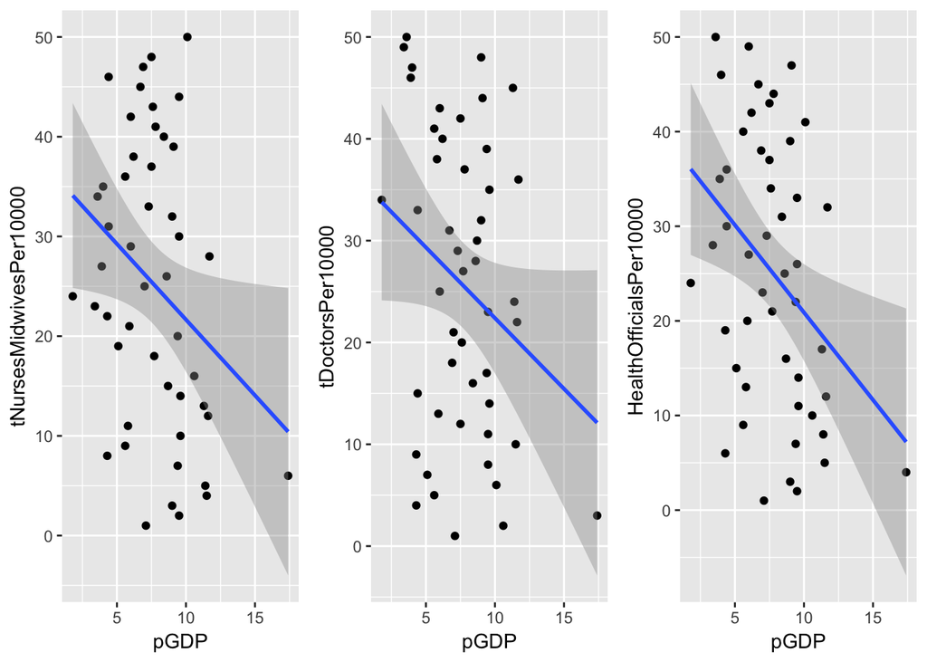

```r
multiplot(t3a1, t3a2, t3a3, cols=3)
```

#### Healthcare outcomes vs Percent Government Spends on Health

```r
t3b1<-ggplot(task3data,aes(pGovSpendHealth,tNursesMidwivesPer10000))+geom_point()+geom_smooth(method = "lm")
```

```r
t3b2<-ggplot(task3data,aes(pGovSpendHealth,tDoctorsPer10000))+geom_point()+geom_smooth(method = "lm")
```

```r
t3b3<-ggplot(task3data,aes(pGovSpendHealth,HealthOfficialsPer10000))+geom_point()+geom_smooth(method = "lm")
```

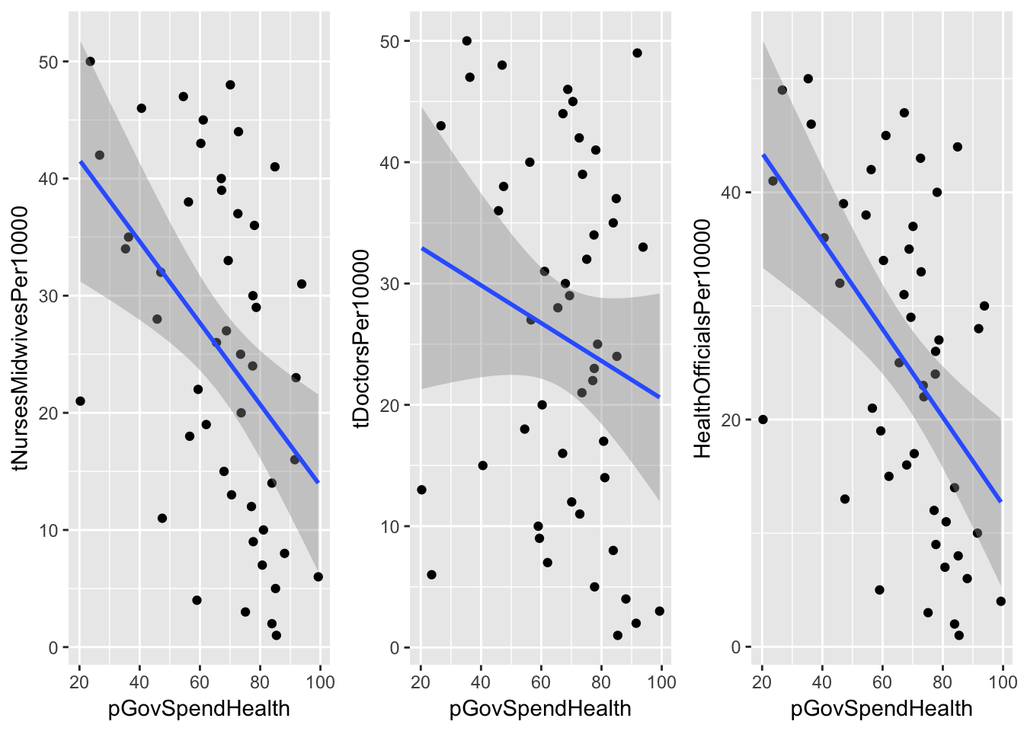

```r
multiplot(t3b1, t3b2, t3b3, cols=3)
```

#### Healthcare outcomes vs Percent Private Sector Spends on Healthcare

```r
t3c1<-ggplot(task3data,aes(pPrivSpendHealth,tNursesMidwivesPer10000))+geom_point()+geom_smooth(method = "lm")
```

```r
t3c2<-ggplot(task3data,aes(pPrivSpendHealth,tDoctorsPer10000))+geom_point()+geom_smooth(method = "lm")
```

```r
t3c3<-ggplot(task3data,aes(pPrivSpendHealth,HealthOfficialsPer10000))+geom_point()+geom_smooth(method = "lm")
```

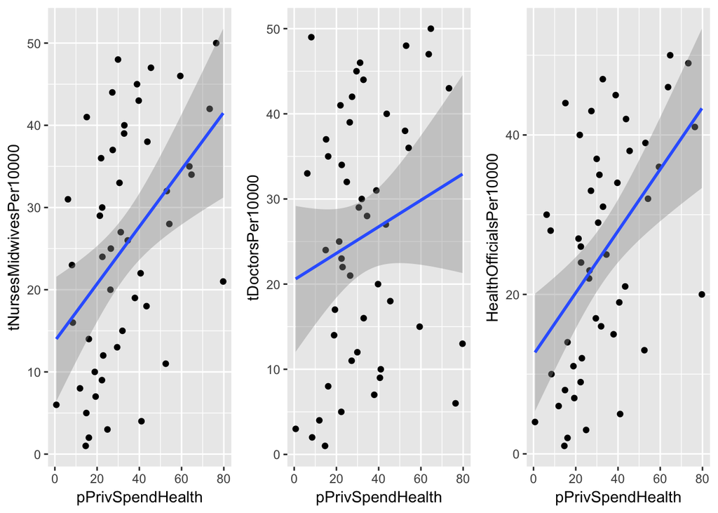

```r
multiplot(t3c1, t3c2, t3c3, cols=3)
```

#### Healthcare outcomes vs the Amount of Dollars Spent on Healthcare

```r
t3d1<-ggplot(task3data,aes(HealthTotal,tNursesMidwivesPer10000))+geom_point()+geom_smooth(method = "lm")
```

```r
t3d2<-ggplot(task3data,aes(HealthTotal,tDoctorsPer10000))+geom_point()+geom_smooth(method = "lm")
```

```r
t3d3<-ggplot(task3data,aes(HealthTotal,HealthOfficialsPer10000))+geom_point()+geom_smooth(method = "lm")
```

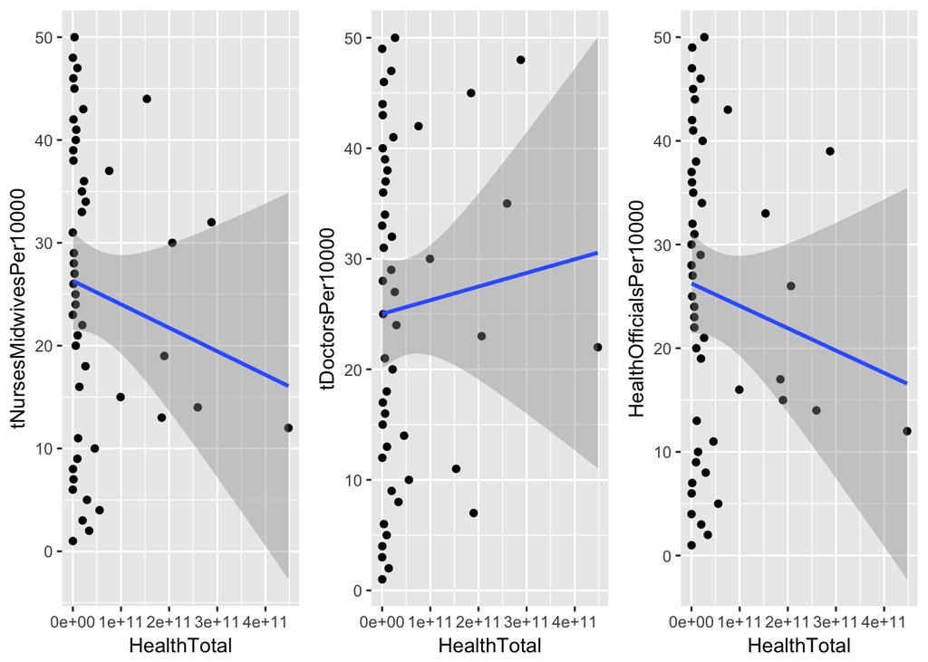

```r
multiplot(t3d1, t3d2, t3d3, cols=3)
```

#### Healthcare outcomes vs the Amount of Dollars Spent by the Government on Healthcare

```r
t3e1<-ggplot(task3data,aes(GovHealth,tNursesMidwivesPer10000))+geom_point()+geom_smooth(method = "lm")
```

```r
t3e2<-ggplot(task3data,aes(GovHealth,tDoctorsPer10000))+geom_point()+geom_smooth(method = "lm")
```

```r
t3e3<-ggplot(task3data,aes(GovHealth,HealthOfficialsPer10000))+geom_point()+geom_smooth(method = "lm")
```

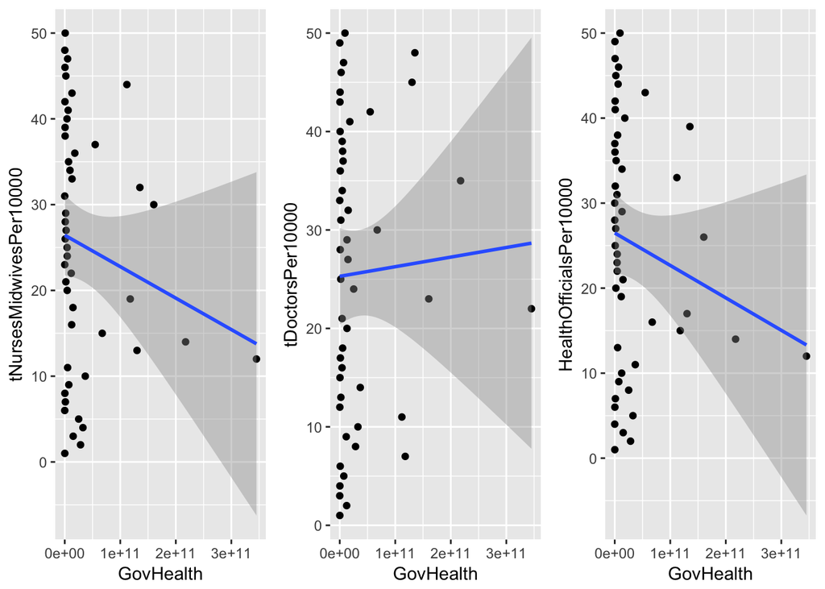

```r
multiplot(t3e1, t3e2, t3e3, cols=3)
```

```r
t3f1<-ggplot(task3data,aes(PrivHealth,tNursesMidwivesPer10000))+geom_point()+geom_smooth(method = "lm")
```

```r
t3f2<-ggplot(task3data,aes(PrivHealth,tDoctorsPer10000))+geom_point()+geom_smooth(method = "lm")
```

```r
t3f3<-ggplot(task3data,aes(PrivHealth,HealthOfficialsPer10000))+geom_point()+geom_smooth(method = "lm")
```

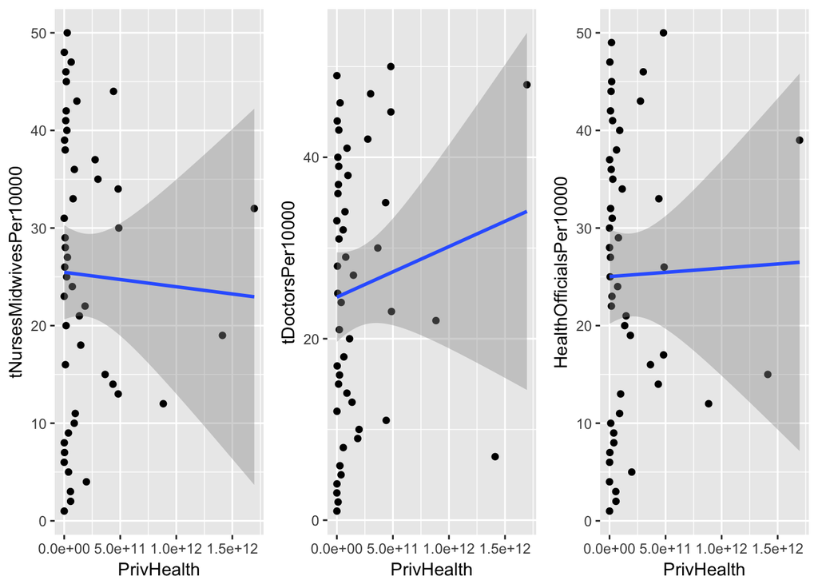

```r
multiplot(t3f1, t3f2, t3f3, cols=3)
```